# ggplot2を利用したデータ可視化の基礎

# 5 描画関数の実行

## 5.1 箱ひげ図

まずはがく長の箱ひげ図を書かせることにしよう．

### 5.1.1 単純な箱ひげ図

箱ひげ図を書かせる命令は`geom_boxplot()`関数となる．この関数の第1引数に`aes()`関数をあたえる．`aes()`関数ではさらにx軸，y軸のデータを設定する．data_irisに含まれている「がく長」の全体のデータを箱ひげ図にしてみよう．データ全体なので，x軸には文字列として”全体”としておく．

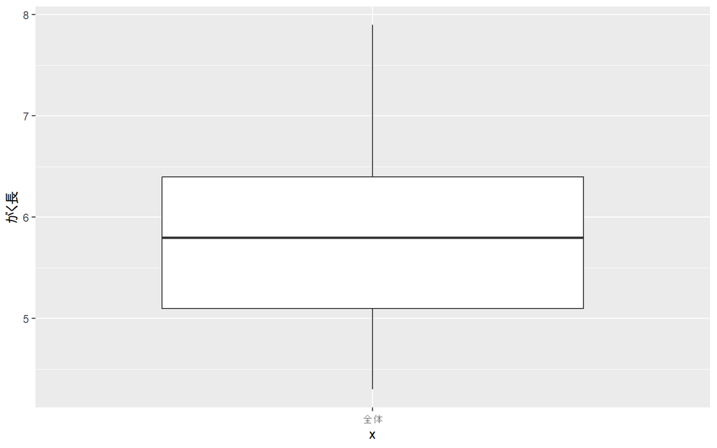

```r
g <- ggplot(data_iris) + geom_boxplot(aes(x="全体", y=がく長))
plot(g)
```

y とxを入れ替えると以下の通りとなる．

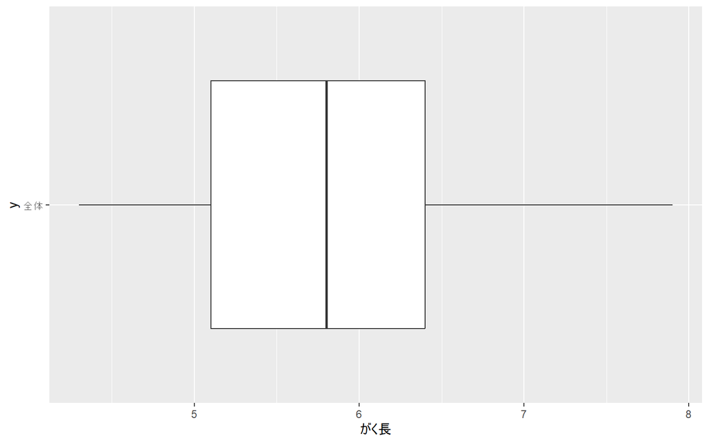

```r
g <- ggplot(data_iris) + geom_boxplot(aes(x=がく長, y="全体"))
plot(g)
```

### 5.1.2 種類ごとの箱ひげ図

上記はあくまでがく長全体を一まとめのデータとして扱ったが，例えば，x軸を種類に設定して，種類ごとの箱ひげ図を書かせたいといった場合には以下の通りにする．先ほどと違い**`種類`にはダブルコーテーションはつかない**．これは**種類はあくまでdata_irisに含まれる変数名であり，単なる文字列であった`"全体"`というのと根本的に異なるものであるため**である．

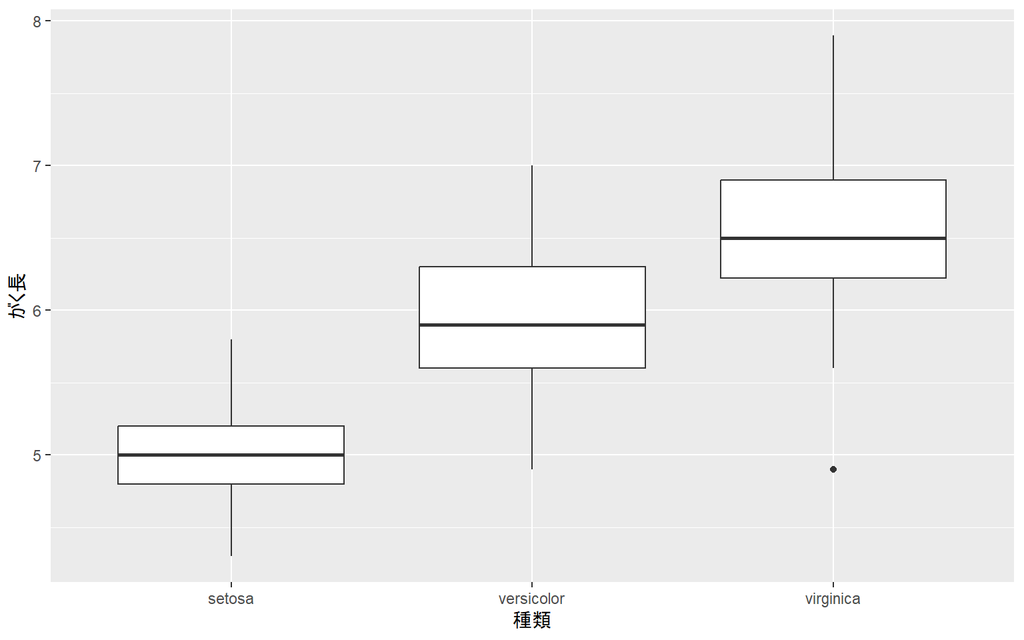

```r
g <- ggplot(data_iris) + geom_boxplot(aes(x=種類, y=がく長))
plot(g)
```

このように箱ひげ図が種類ごとに描かれる．

#### 5.1.2.1 種類ごとに塗り分ける

箱ひげ図に色を塗りつぶしたい場合には，`aes()`に`fill`(塗りつぶし)の設定を与える．塗分けは箱ひげ図の場合にはグループ単位で行いたいであろう．そういう場合には，グループ分けに使っている変数，すなわち種類を与えると良い．

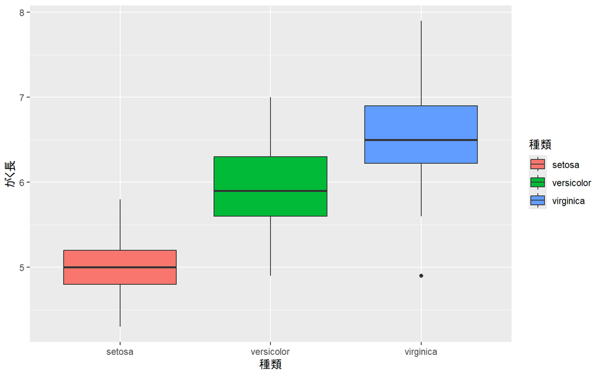

```r
g <- ggplot(data_iris) + geom_boxplot(aes(x=種類, y=がく長, fill=種類))
plot(g)
```

塗りつぶしではなく，枠のみに色を付けたい場合には，`fill`の代わりに，`color`の設定を与える．

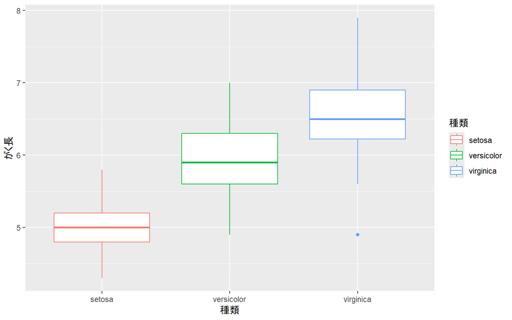

```r
g <- ggplot(data_iris) + geom_boxplot(aes(x=種類, y=がく長, color=種類))
plot(g)
```

fillとcolorの両方を設定することもできるが，それをすると，枠線と塗りつぶしの色が同じになってしまい，中央値が見えなくなるので，いずれか一方にするべきである．

#### 5.1.2.2 箱の幅を変える

`geom_boxplot()`の第2引数（`aes()`関数の外の引数）としてwidthを与える．デフォルトは0.75に設定されてる．

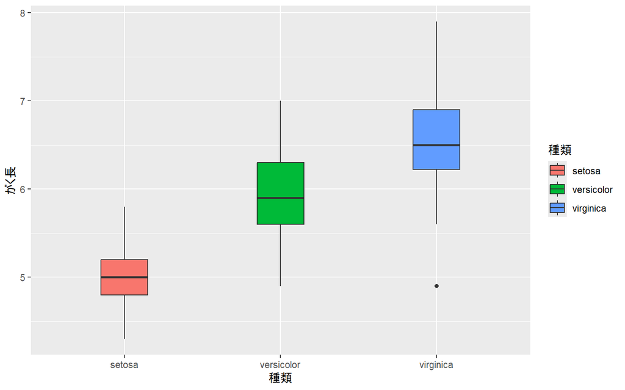

```r
g <- ggplot(data_iris) + geom_boxplot(aes(x=種類, y=がく長, fill=種類),width=0.3 )
plot(g)
```

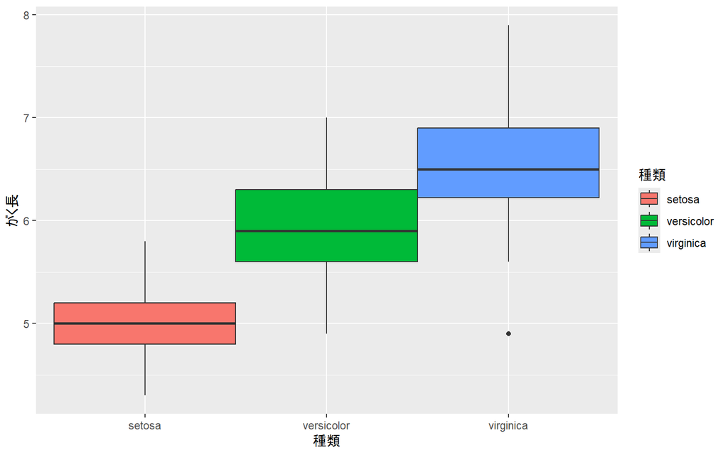

```r
g <- ggplot(data_iris) + geom_boxplot(aes(x=種類, y=がく長, fill=種類),width=1.0 )
plot(g)
```

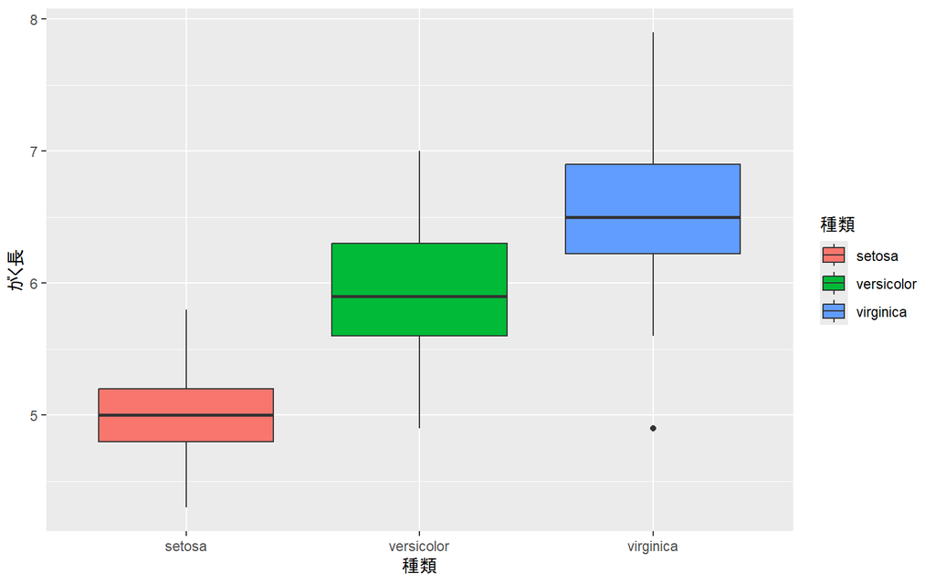

```r
g <- ggplot(data_iris) + geom_boxplot(aes(x=種類, y=がく長, fill=種類),width=0.75)
plot(g)
```

### 5.1.3 複数の変数の箱ひげ図

今までは「がく長」のみを描画してきたが，「がく幅」や「花びら長」なども同時に描画させたい場合には，以下のようにgeom_boxplotを各変数に対して設ける．`x=`で記載されるものはあくまでラベルとなるため，ダブルコーテーション(““)が必要となる．

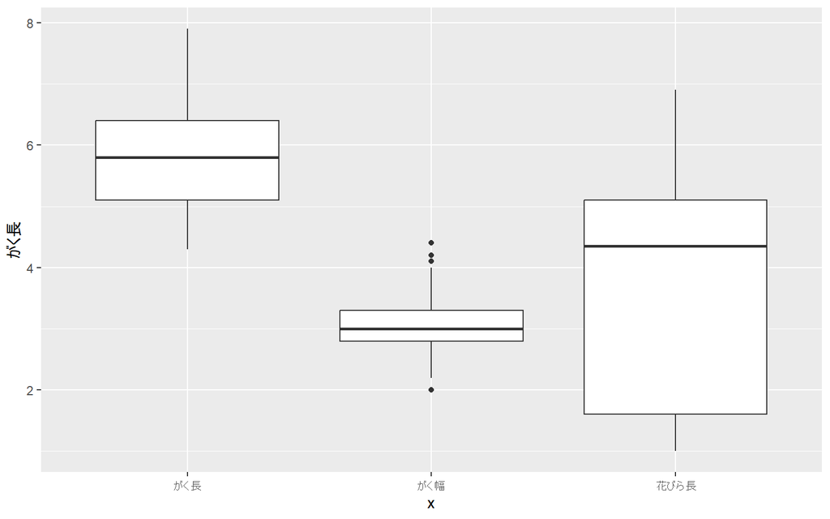

```r
g <- ggplot(data_iris) +
  geom_boxplot(aes(x="がく長",y=がく長))+
  geom_boxplot(aes(x="がく幅", y=がく幅))+
  geom_boxplot(aes(x="花びら長", y=花びら長))

plot(g)
```

なお，このようにした場合には，種類ごとに分けることはできなくなる（x軸が変数に対応する形になるので，種類に対応させる軸がなくなる）．

#### 5.1.3.1 変数ごとに塗り分ける

塗色をしたい場合には，`fill`や`color`の設定を与える．以下では`fill`を設定している．この例のように，`fill`に変数名を設定すると，その変数名に従って色分けされる．

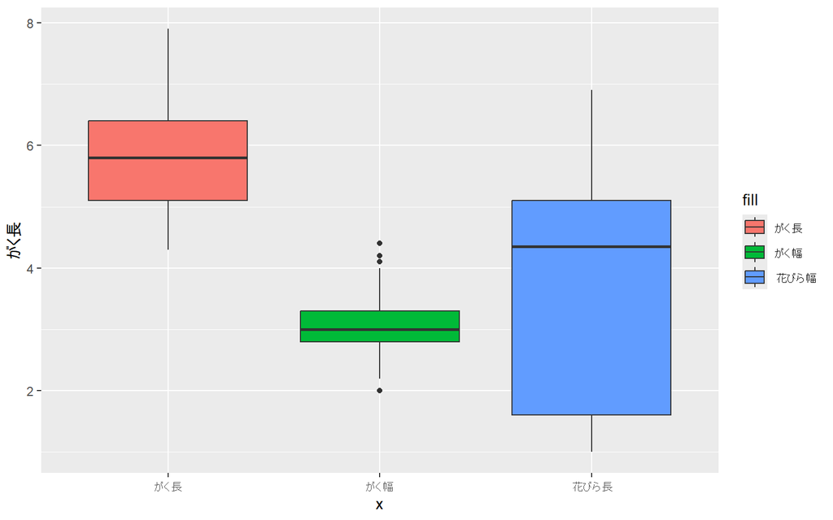

```r
g <- ggplot(data_iris) +
  geom_boxplot(aes(x="がく長",y=がく長, fill="がく長"))+
  geom_boxplot(aes(x="がく幅", y=がく幅, fill="がく幅"))+
  geom_boxplot(aes(x="花びら長", y=花びら長, fill="花びら幅"))

plot(g)
```

colorを設定した場合．

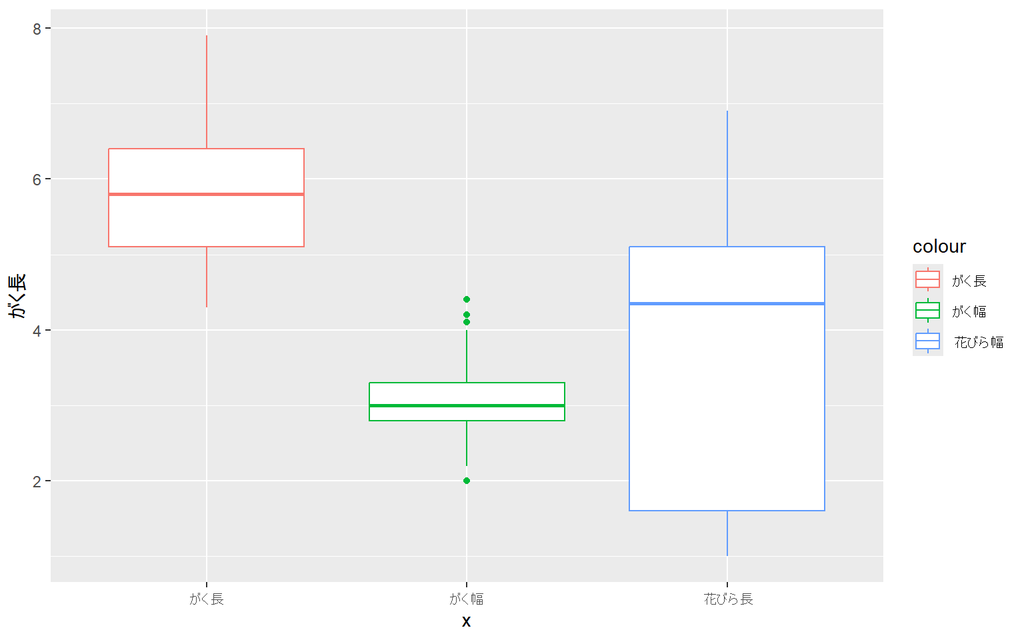

```r
g <- ggplot(data_iris) +
  geom_boxplot(aes(x="がく長",y=がく長, color="がく長"))+
  geom_boxplot(aes(x="がく幅", y=がく幅, color="がく幅"))+
  geom_boxplot(aes(x="花びら長", y=花びら長, color="花びら幅"))

plot(g)
```

このデータは，ある地域Aとある地域Bの高校生をランダムに500人ずつ抽出し，それぞれの大学入試共通テストの数学IA，数学IIB，国語をデータ化したものである．このデータを使って,以下の問に答えよ

1. このデータをhead()関数とsummary()関数を使って確認せよ．なお，地域については要因型に変換しておくこと．
2. 数学IAについて地域別の箱ひげ図を作成せよ.
3. 各科目の箱ひげ図を描画せよ．

## 5.2 点プロット

### 5.2.1 基本の点プロット

基本は`geom_point()`である．引数として`aes()`を使ってx，yを設定する．以下は，がく長全体のデータをプロットしたものである．

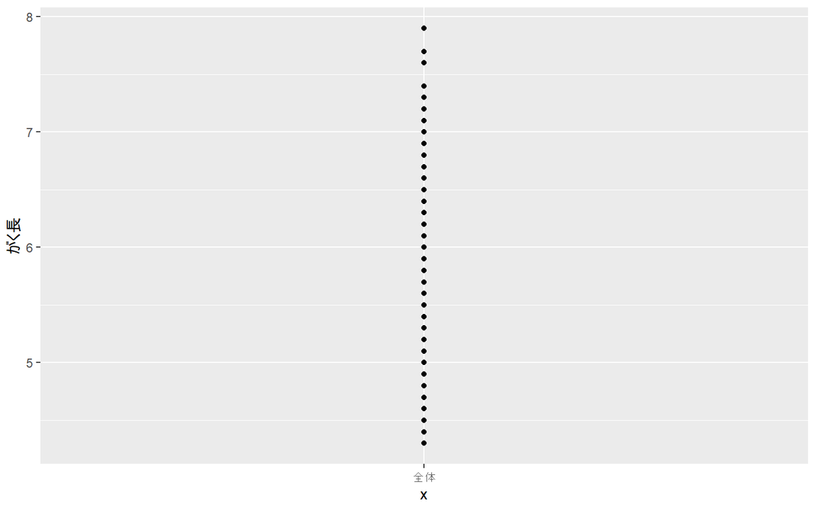

```r
g <- ggplot(data_iris)+geom_point(aes(x="全体", y=がく長))
plot(g)
```

つづいて，種類ごとのがく長をプロットした例である．

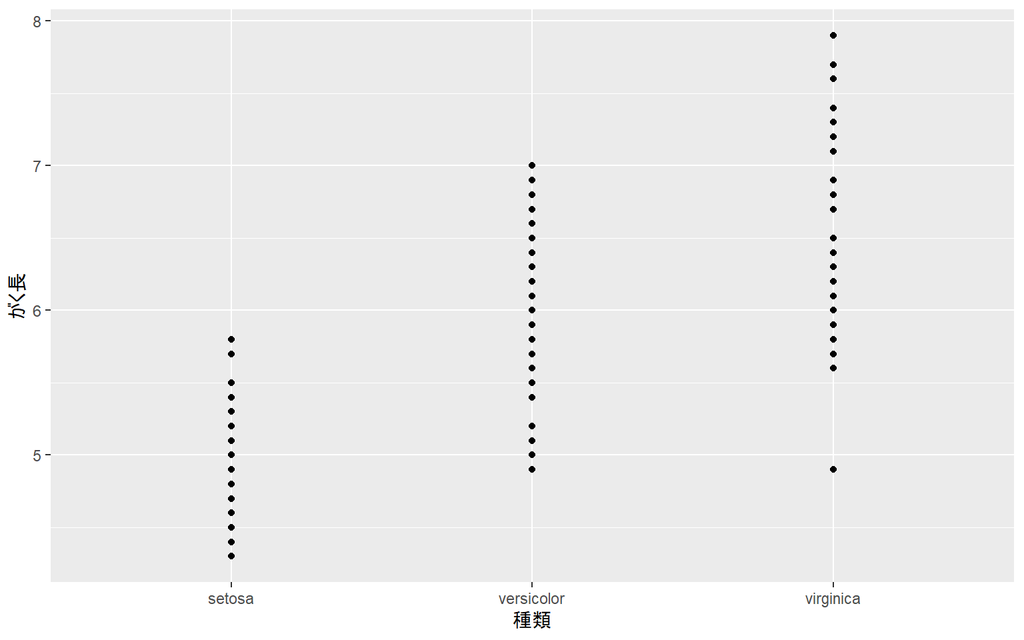

```r
g <- ggplot(data_iris)+geom_point(aes(x=種類, y=がく長))
plot(g)
```

全体にしても種類ごとにしても，がく長は0.1刻みで測定されているため，値が同じものが含まれている．上記の設定では，それらは全部重なってしまうため，上記のようなプロットとなる．

### 5.2.2 点をばらつかせる（Jitter）

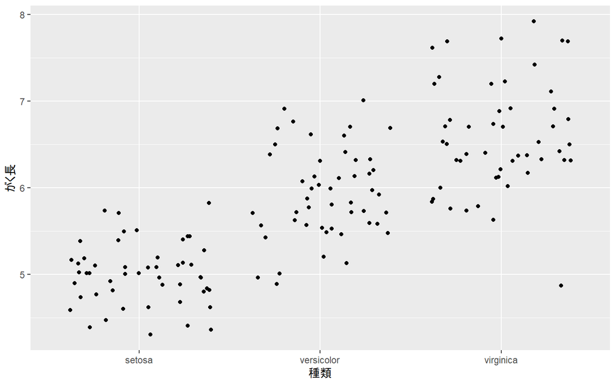

```r
g <- ggplot(data_iris)+geom_jitter(aes(x=種類, y=がく長))
plot(g)
```

水平方向にランダムにばらついたことによって，同じ値を取っているものがどれだけあるかがある程度視覚的に把握できるようになる．

もう一度描画させると，先ほどと違うばらつき方になる．

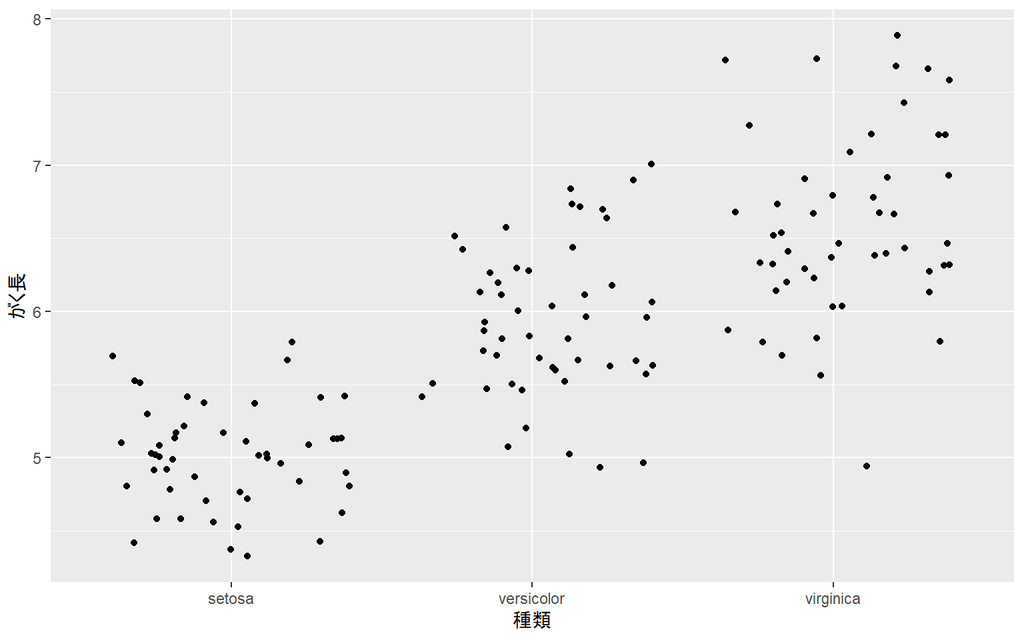

```r
g <- ggplot(data_iris)+geom_jitter(aes(x=種類, y=がく長))
plot(g)
```

**Jitterではなく度数分布にする**

先の例では点をプロットするときに横方向にランダム化させるjitter表示にしていたが，度数分布にすることもできる． 度数分布の場合には，`geom_jitter()`の代わりに`geom_dotplot()`関数を用いる．引数がやや多いので以下に表で示す．

| 引数名 | 内容 |
| --- | --- |
| aes(x=, y=) | x軸，y軸の設定 |
| binaxis | どちらの軸の変数についての度数分布にするのか |
| dotsize | プロットする点のサイズ |
| stackdir | どの方向にプロットしていくか．Up(右向き), down(左向き), center(中心ぞろえ)のいずれか |
| binwidth | 度数分布における区間幅の設定 |
| position | `position_nudge()`関数によって描画開始をそれぞれのグループのx軸の中心からどちら向き（正か負か）にどれだけ離すかの設定する．stackdirをcenterにした場合には中心がずれる |

以下に，実際にいくつか例示してみる．なお，1行のソースコードが長くなってきたので，見やすさのため`+`で改行しているほか，関数内でも引数単位で適宜改行を入れている．

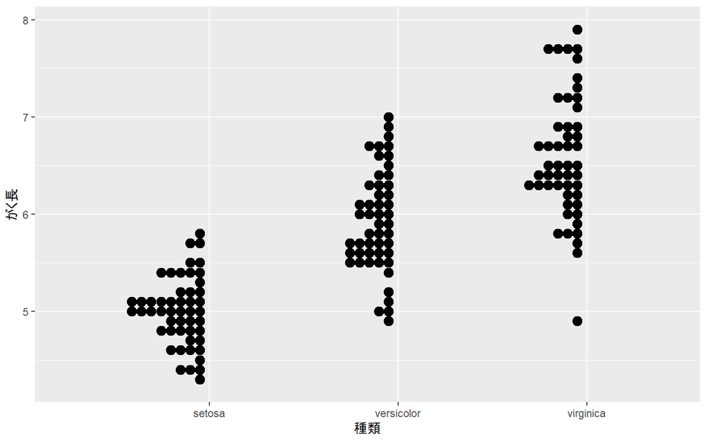

```r
g <- ggplot(data_iris)+
  geom_dotplot(aes(x=種類, y=がく長), binaxis = "y", dotsize = 1.0, stackdir = "down",
               binwidth = 0.1, position = position_nudge(-0.025))
plot(g)
```

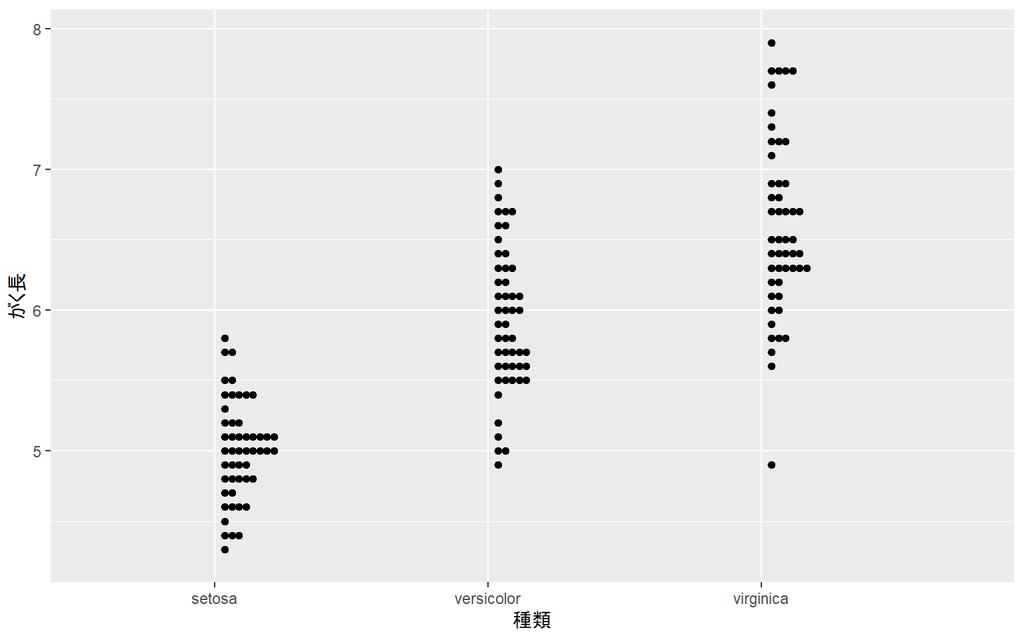

```r
g <- ggplot(data_iris)+
  geom_dotplot(aes(x=種類, y=がく長), binaxis = "y", dotsize = 0.50, stackdir = "up",
               binwidth = 0.1, position = position_nudge(0.025))
plot(g)
```

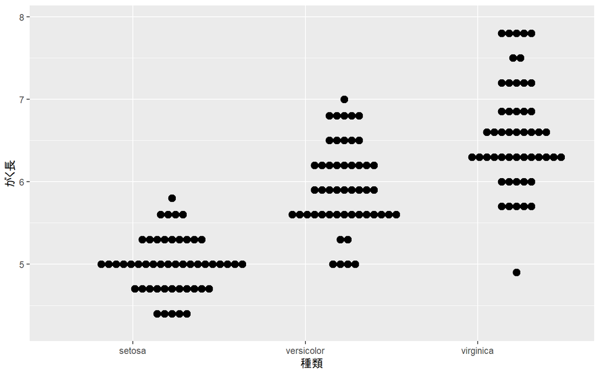

```r
g <- ggplot(data_iris)+
  geom_dotplot(aes(x=種類, y=がく長), binaxis = "y", dotsize = 0.3, stackdir = "center",
               binwidth = 0.3, position = position_nudge(0.225))
plot(g)
```

以下はbinaxisをxに設定しているためエラーとなる（xはグループ分け変数であり，概念上度数分布というものが存在しないので）．

```r
g <- ggplot(data_iris)+
  geom_dotplot(aes(x=種類, y=がく長), binaxis = "x", dotsize = 0.3, stackdir = "up",
               binwidth = 0.1, position = position_nudge(0.025))
plot(g)
```

```
## Error in `geom_dotplot()`:
## ! Problem while setting up geom.
## ℹ Error occurred in the 1st layer.
## Caused by error in `compute_geom_1()`:
## ! `geom_dotplot()` requires the following missing aesthetics: y.
```

### 5.2.3 色やプロット範囲の幅を変える

箱ひげ図の時と同様に，色や幅を変えることができる．色については`fill`（塗りつぶし）ではなく`color`を設定したり，`Width`を設定したりして，色や幅を変えることができる．

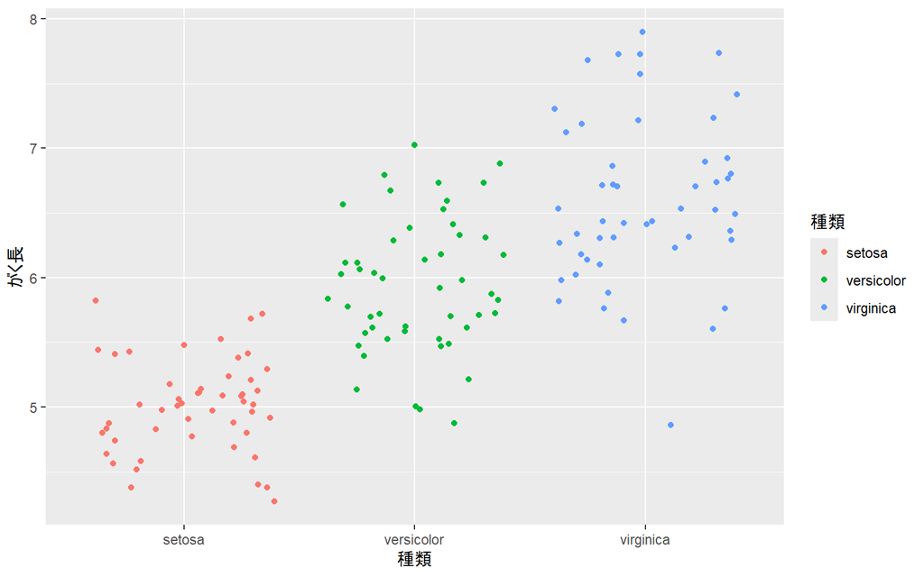

```r
g <- ggplot(data_iris)+geom_jitter(aes(x=種類, y=がく長, color=種類))
plot(g)
```

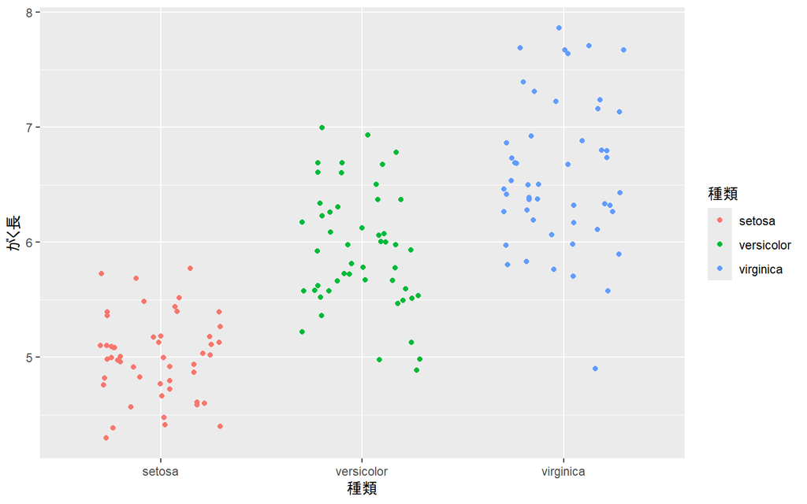

```r
g <- ggplot(data_iris)+geom_jitter(aes(x=種類, y=がく長, color=種類), width = 0.3)
plot(g)
```

### 5.2.4 箱ひげ図との重ね合わせ

点のプロットと箱ひげ図を重ねることもできる．以下のように`geom_boxplot()`と`geom_dotplot()`や`geom_jitter()`を`+`でつなげればよい．

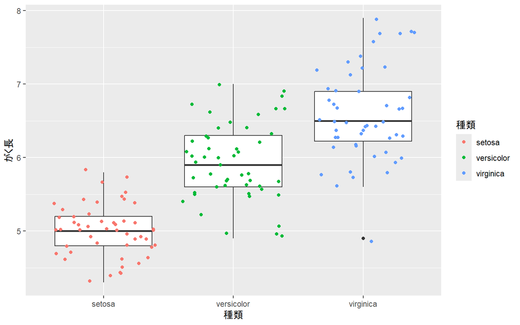

```r
g<- ggplot(data_iris)+
  geom_boxplot(aes(x=種類,y=がく長))+
  geom_jitter(aes(x=種類, y=がく長, color=種類))
plot(g)
```

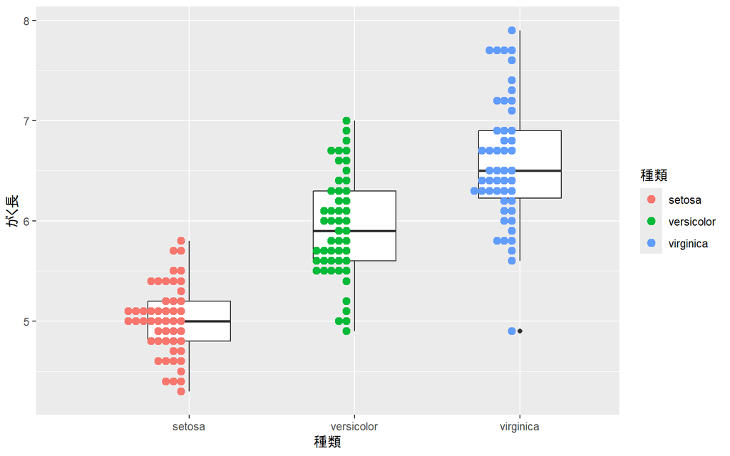

```r
g<- ggplot(data_iris)+
  geom_boxplot(aes(x=種類,y=がく長), width=0.5)+
  geom_dotplot(aes(x=種類, y=がく長, color=種類, fill=種類), binaxis = "y",
               dotsize = 0.75, stackdir = "down",binwidth = 0.1,
               position = position_nudge(-0.025))
plot(g)
```

`aes()`（エステティック）関数の設定項目はx，y軸とfill(塗りつぶし), color(線や点の色設定)が出てきているが，それ以外に以下のようなものがある．

| 項目 | 内容 |
| --- | --- |
| x, y | x軸に設定する変数，y軸に設定する変数 |
| color | 点や線の色 |
| fill | 面の色 |
| alpha | 不透明度 (0が透明，1が不透明) |
| size | 点や文字の大きさ，線の太さ |
| shape | 点の形 |
| linetype | 線の種類 |
| group | 反復試行の折れ線グラフなど，色や形はそのままで切り分けたいときに． |
| xmin, xmax, ymin, ymax, xend, yend | ものによってつかう． |

極めて多いエラーとして，各`geom()`関数を実行していくときに，前の行の末尾に`+`を付け忘れたり，最後の行の末尾に`+`をつけたりしてしまうことがよくある． もし，エラーが出てグラフ描画ができなかった場合には，これらのミスをしていないかを確認してみてほしい．

先ほど読み込んだ大学入試共通テストの得点データ（数学IA，数学IIB，国語）を使って以下の問に答えよ．

1. 各科目の箱ひげ図に個々の得点のjitterプロットを重ねて描画せよ．箱ひげ図は色付けはせず，Jitterプロットは色付けすること．
2. 数学IAについて地域ごとの箱ひげ図に，地域ごとの個々の得点のjtterプロット重ねて描画せよ．箱ひげ図は色付けはせず，Jitterプロットは色付けすること．

## 5.3 棒グラフとエラーバー

平均を棒グラフとして，さらに標準偏差や信頼区間をエラーバーとして描く，というケースは非常に多い．そこで以下ではそういう棒グラフの作成方法を説明する．

### 5.3.1 棒グラフの基本

流れとしては平均と標準偏差の求め，それを元のデータとは別のデータフレームに格納し，そのデータフレームを用いて描画する，という流れとなる．

用いるggplot2の関数は`geom_bar()`と`geom_errorbar()`である．

`geom_bar()`は棒グラフを描く関数である．第1引数として`aes()`関数を与え，x軸とy軸を設定する．第2引数には`stat="identity"`を与える．これは「与えたデータをそのまま使う」という意味である．第3引数にはwidthを与える．これは棒の幅を設定する．ただ，第3引数は省略することもできる．

`geom_errorbar()`はエラーバーを描く関数である．第1引数として`aes()`関数を与え，x軸，y軸，ymin，ymaxを設定する．x軸,y軸は`geom_bar()`に与えたものと同じもの与える．yminはエラーバーの下限，ymaxはエラーバーの上限を示す．一般的には平均$\pm$標準偏差もしくは信頼区間の上限・下限が与えられる．widthはエラーバーの幅を設定する．widthを省略すると，上限・下限を示す水平方向の線分が描かれなくなる．

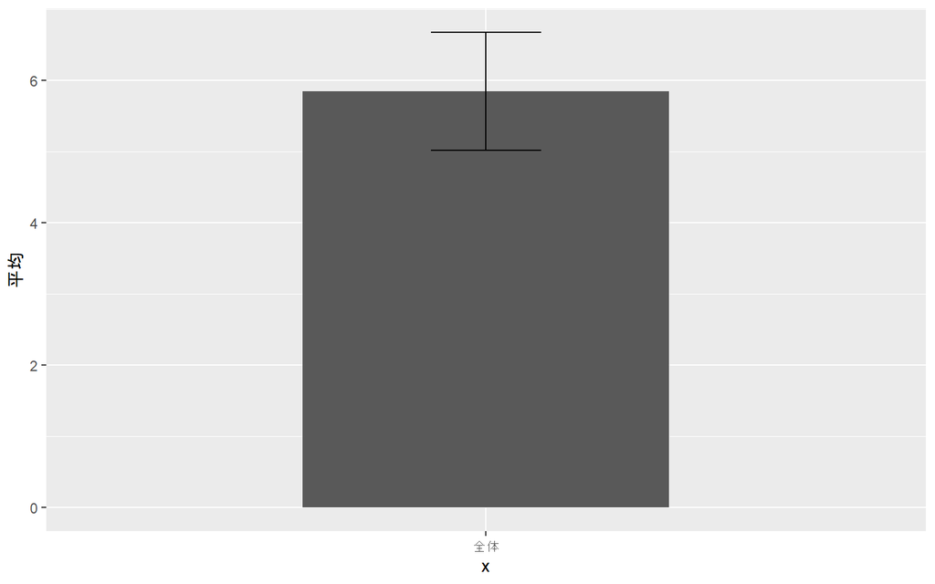

```r
#データの準備
平均 <- mean(data_iris$がく長)
標準偏差 <- sd(data_iris$がく長)

d <- data.frame( # それぞれ1つずつの値しか格納されていないが，あくまでデータフレームである
  平均 = 平均,
  標準偏差 = 標準偏差
)

g<-ggplot(d)+
  geom_bar(aes(x="全体",y=平均), stat="identity",width = 0.5)+
  geom_errorbar(aes(x="全体",y=平均,ymin=平均-標準偏差, ymax=平均+標準偏差),width=0.15)
plot(g)
```

### 5.3.2 種類ごとに分けた棒グラフにしたい

aggregate()関数グループごとのデータを用意した上で，以下のようにする．

```r
#データの準備
d.mean <- aggregate(がく長~種類,data_iris, mean)
d.sd <- aggregate(がく長~種類,data_iris, sd)
d.mean
```

```
##         種類 がく長
## 1     setosa  5.006
## 2 versicolor  5.936
## 3  virginica  6.588
```

```r
d.sd
```

```
##         種類    がく長
## 1     setosa 0.3524897
## 2 versicolor 0.5161711
## 3  virginica 0.6358796
```

```r
d2 <- data.frame(
  種類 = d.mean$種類,
  平均 = d.mean$がく長,
  標準偏差= d.sd$がく長
)
print(d2)
```

```
##         種類  平均  標準偏差
## 1     setosa 5.006 0.3524897
## 2 versicolor 5.936 0.5161711
## 3  virginica 6.588 0.6358796
```

[figure not shown]

```r
 g <- ggplot(d2)+
  geom_bar(aes(x=種類,y=平均,fill=種類),stat="identity")+
  geom_errorbar(aes(x=種類,y=平均,ymin=平均-標準偏差, ymax=平均+標準偏差),width=0.15)
plot(g)
```

さらに，平均値自体を棒グラフに重ねて記述したい場合には以下のよう`geom_text()`を用いるる．vjustは，テキストの位置を調整するためのパラメータで，数値が大きいほど下に移動する．負の値にした場合は棒グラフよりも上の表記される．

[figure not shown]

```r
g <- ggplot(d2)+
  geom_bar(aes(x=種類,y=平均,fill=種類),stat="identity")+
  geom_errorbar(aes(x=種類,y=平均,ymin=平均-標準偏差, ymax=平均+標準偏差,width=0.15))+
  geom_text(aes(x=種類,y=平均,label=round(平均,1)),vjust=5)
plot(g)
```

今まで，キャンバスを作った際にデータフレームを与え，その後，描画をする際にxとyを指摘してきたが，キャンバスを作るときにxとyも指定することができる．そうすると，描画をするときに，いちいちx，yを指定しなくても良くなる．以下に例を示す．

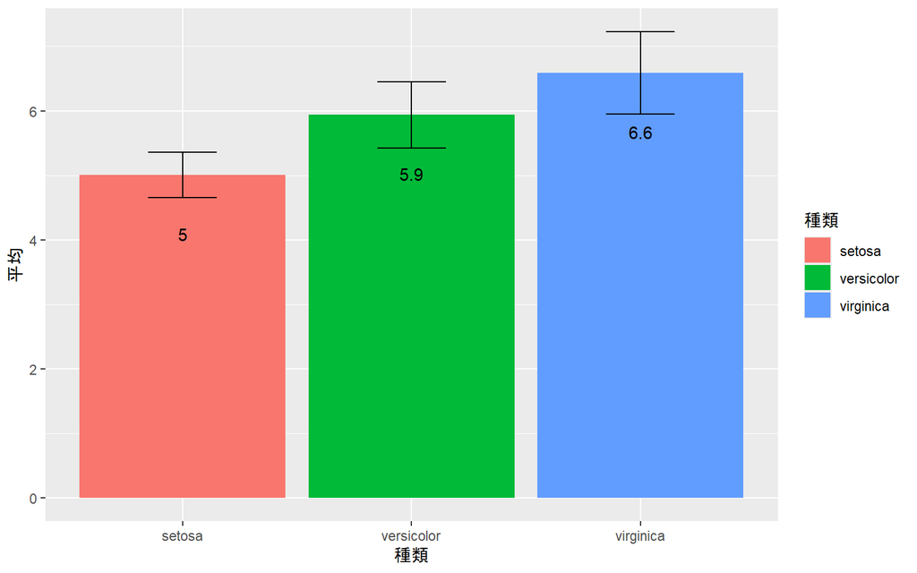

```r
g <- ggplot(d2)+
  geom_bar(aes(x=種類,y=平均,fill=種類),stat="identity")+
  geom_errorbar(aes(x=種類,y=平均,ymin=平均-標準偏差, ymax=平均+標準偏差,width=0.3))+
  geom_text(aes(x=種類,y=平均,label=round(平均,1)),vjust=5)
plot(g)
```

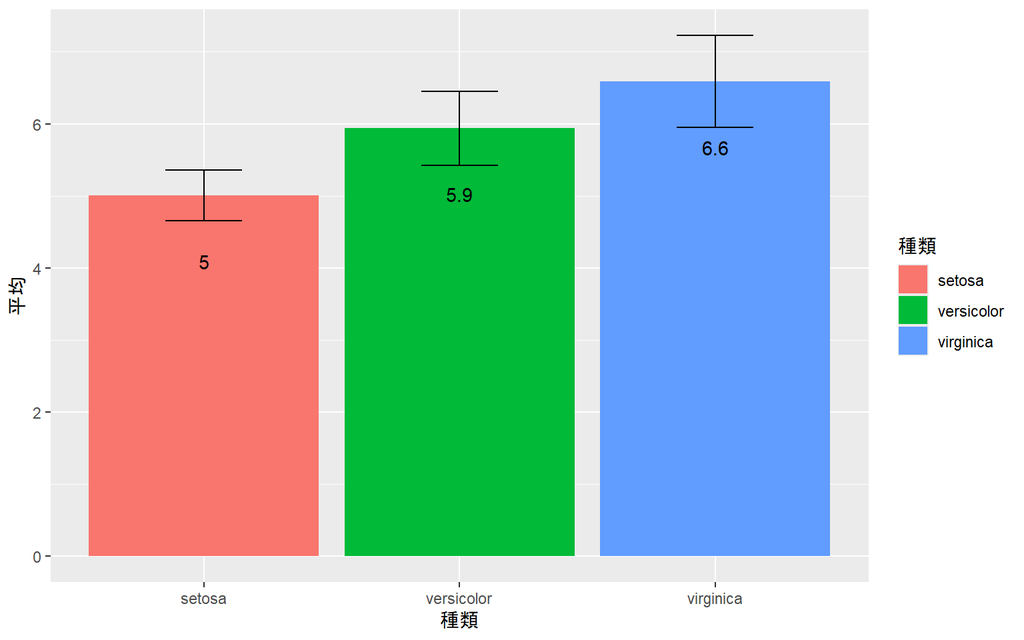

```r
g <- ggplot(d2,aes(x=種類,y=平均))+
  geom_bar(aes(fill=種類),stat="identity")+
  geom_errorbar(aes(ymin=平均-標準偏差, ymax=平均+標準偏差,width=0.3))+
  geom_text(aes(label=round(平均,1)),vjust=5)
plot(g)
```

**データそのものを使って描く方法**

データそのものを使って描く場合には以下のようにする． ポイントは以下の通りである．

- `geom_bar`の`stat`を`summary`に設定し，`fun.data`に平均と標準偏差を求める関数である`mean_sdl`に設定するか，`fun`に平均を求める関数である`mean`を設定することである．
- `geom_errorbar`の`stat`を同じく`summary`に設定し，`fun.data`に平均と標準偏差を求める関数である`mean_sdl`に設定する．さらに`fun.args`には`mean_sdl`関数の引数である`mult`を`1`に設定することで，`1`倍の標準偏差を算出させる．
  - `mean_sdl`は`Hmisc`パッケージに含まれている`smean.sdl`という関数を用いて平均と標準偏差を算出してくれる関数である．この`smean_sdl`関数では，第2引数として`mult`という引数があり，これを`1`に指定すると1*標準偏差が，`2`とすると2*標準偏差が算出されるようになる．もし引数を設定しなかった場合には，デフォルト値をとして2に自動で設定される．
  - `mean_sdl`を実施するためには`Hmisc`パッケージをインストールしておく必要がある．
- `geom_text`でlabelを与える際に`after_stat()`関数を使って，`stat`で求めた値を使うように設定した上で，`stat`と`fun`をそれぞれ`summary`と`mean`に設定する．

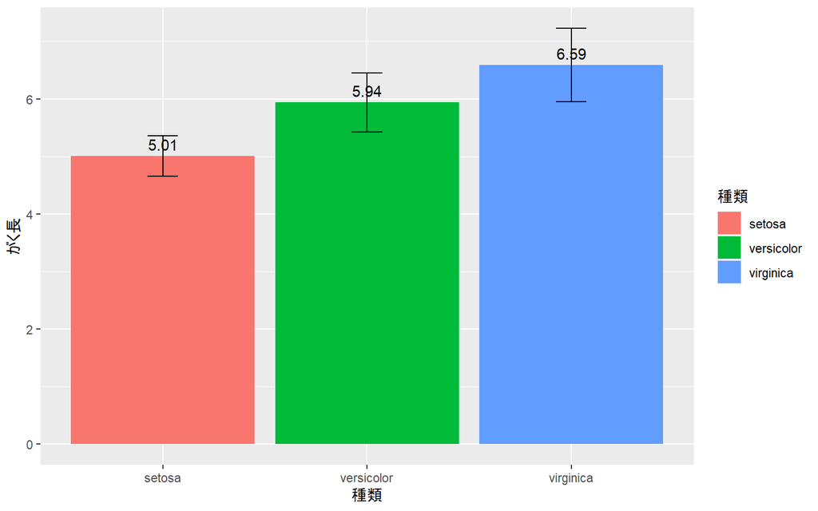

```r
g <- ggplot(data_iris, aes(x=種類,y=がく長,fill=種類))+
  geom_bar(stat = "summary", fun.data = "mean_sdl")+ # geom_bar(stat = "summary", fun = "mean") でもよい
  geom_errorbar(stat = "summary", fun.data = "mean_sdl", fun.args = list(mult = 1), width=0.15)+
  geom_text(aes(label = round(after_stat(y), 2)), stat = "summary", fun = "mean", vjust = -0.5)
plot(g)
```

なお，上記はエラーバーとして**標準偏差**を表示させる方法であるが，エラーバーとして**標準誤差**を使う場合には，もう少しシンプルに書く事が出来る．

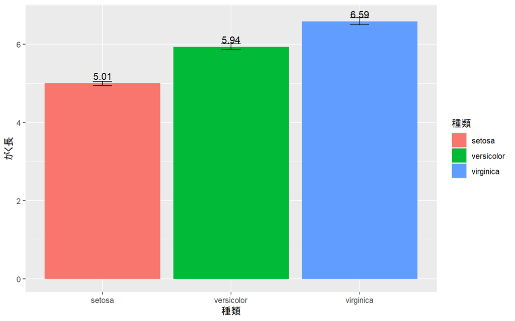

```r
g <- ggplot(data_iris, aes(x=種類,y=がく長,fill=種類))+
  geom_bar(stat = "summary",fun.data = mean_se)+
  geom_errorbar(stat = "summary", fun.data = "mean_se", width=0.15)+
  geom_text(aes(label = round(after_stat(y), 2)), stat = "summary", fun = "mean", vjust = -0.5)
plot(g)
```

先ほど読み込んだ大学入試共通テストの得点データ（数学IA，数学IIB，国語）を使って以下の問に答えよ．

1. 各科目について平均値と標準偏差を求め，それを棒グラフとエラーバーで描画せよ．エラーバーは標準偏差を用いること．また，それぞれの平均の値も棒グラフに重ねて記述すること．
2. 数学IAについて，地域ごとの平均と標準偏差を求め，それを棒グラフとエラーバーで描画せよ．エラーバーは標準偏差を用いること． また，それぞれの平均の値も棒グラフに重ねて記述すること．

## 5.4 ヒストグラム

度数分布表（設定した区間幅のそれぞれに含まれるサンプル数を表にしたもの）をグラフ表示したものをヒストグラムと呼ぶ．ヒストグラムを作成するには `geom_histgram()`を使う

### 5.4.1 geom_histgram()を使う

`geom_histgram`を使う場合，区間幅はデフォルトではデータの範囲を30等分した値が自動的に設定されるが，`binwidth`を設定することによって任意の区間幅に設定することもできる．以下の例では，がく長の値を0.1単位で区切っている．

データを度数分布表やヒストグラムを描く際に，データを区間に分ける処理をbinningと呼ぶ．このため，`geom_histgram()`関数で区間幅の引数が`binwidth`となっている．

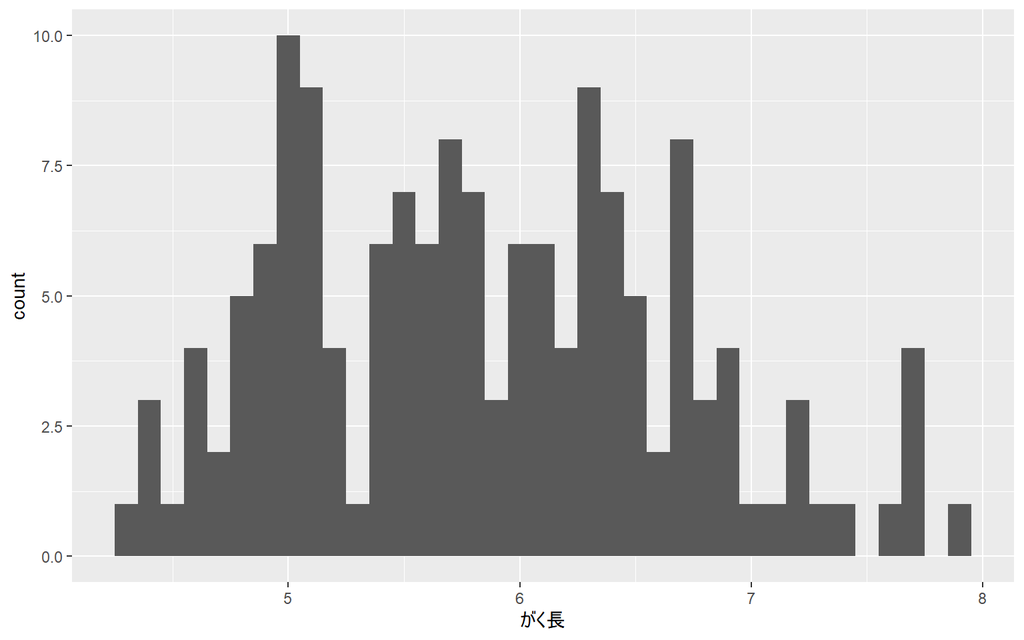

```r
g <- ggplot(data_iris)+
  geom_histogram(aes(x=がく長), binwidth = 0.1)
plot(g)
```

これだと区間の境界がわかりにくいので，境界を描かせるためには以下のようにする．

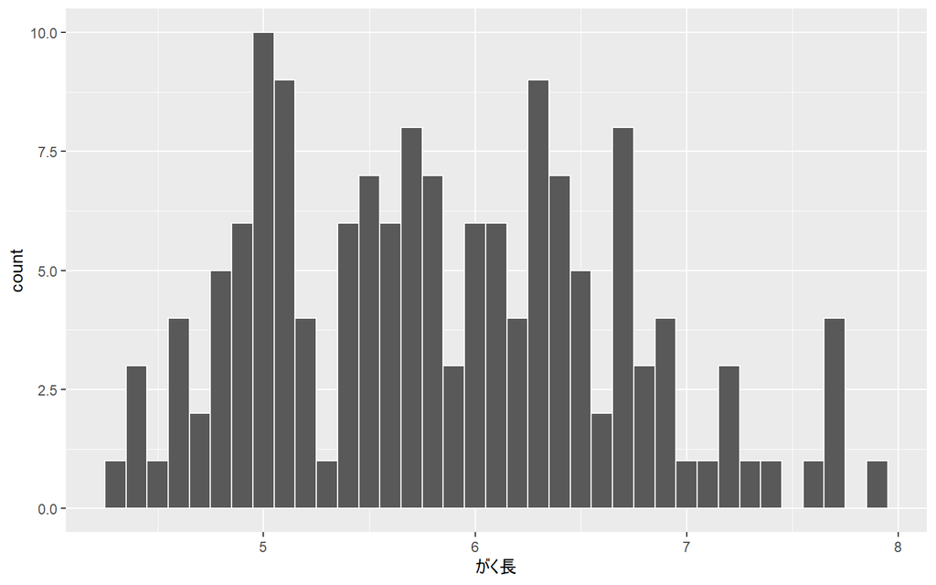

```r
g <- ggplot(data_iris)+
  geom_histogram(aes(x=がく長),color="white", binwidth = 0.1)
plot(g)
```